# Bayesian CFA with blavaan: Non-informative and informative priors with comparisons

David Kaplan

```r
library(rstan)
library(blavaan)
```

# Read in data

```r
CanadaCFA <-read.csv("~/desktop/Canada.csv",header=TRUE) # browse to select data
CanadaCFA <- subset(CanadaCFA, select=c(ASBR08A,ASBR08B,ASBR08C,ASBR08D,ASBR08E,ASBR08F,ASBR08G))
names(CanadaCFA) <- c("dowell","easy","harder","interesting","difficultwords","teacherpraise","otherthings")

######
# dowell - I usually do well in reading
# easy - Reading is easy for me
# harder - Reading is harder for me than for many of my classmates
# interesting - If a book is interesting, I don’t care how hard it is to read
# difficultwords - I have trouble reading stories with diffi cult words
# teacherpraise - My teacher tells me I am a good reader
# otherthings - Reading is harder for me than any other subject
#######

CanadaCFA <- CanadaCFA[1:2000,] # Cutting down the sample size
CanadaCFA[CanadaCFA==999999]=NA
CanadaCFA <- na.omit(CanadaCFA)
```

# blavaan is a very powerful package for Bayesian structural equation modeling and factor analysis which uses the lavaan syntax but is also a front end for Stan.

We specify a CFA model with two factors and non-informative default priors

```r
CanadaCFAmodel1 <- ' PosRead =~ dowell+easy+interesting
                    NegRead =~ harder+difficultwords+otherthings'
```

Here we run the analysis and obtain the summary. The number of chains is 3 by default. We control the number of burnin and post-burnin samples

```r
CFAfitNonINf <- bcfa(CanadaCFAmodel1, data=CanadaCFA, burnin = 5000, sample=5000,bcontrol=list(cores=4))
```

```
## Computing posterior predictives...
```

We can look at the default priors used by blavaan

```r
blavInspect(CFAfitNonINf, "dp")
```

```
##                nu             alpha            lambda              beta
##    "normal(0,32)"    "normal(0,10)"    "normal(0,10)"    "normal(0,10)"
##             theta               psi               rho             ibpsi
## "gamma(1,.5)[sd]" "gamma(1,.5)[sd]"       "beta(1,1)" "wishart(3,iden)"
##               tau             delta
## "normal(0,10^.5)" "gamma(1,.5)[sd]"
```

# Trace and density plots

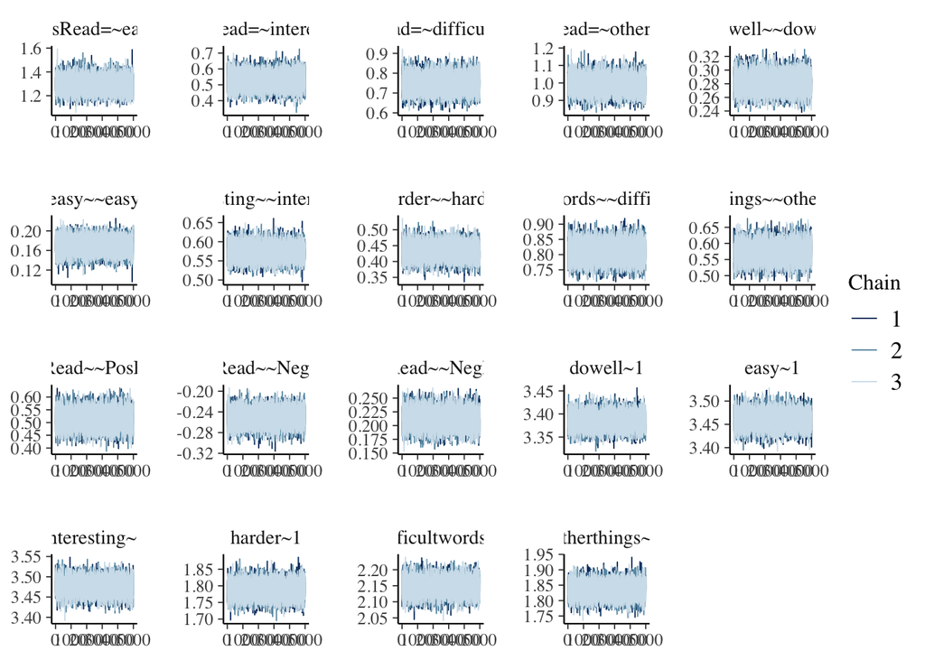

```r
plot(CFAfitNonINf,plot.type=c("trace"))
```

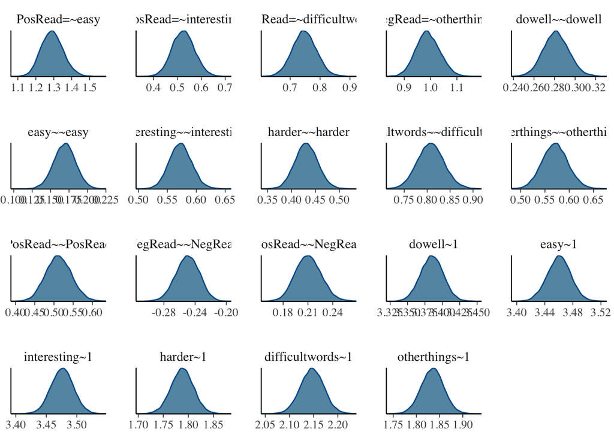

```r
plot(CFAfitNonINf,plot.type=c("dens"))
```

The convergence diagnostics look good

# Results

```r
blavInspect(CFAfitNonINf, "postmean")
```

```
##                  PosRead=~easy           PosRead=~interesting
##                      1.2917320                      0.5250898
##        NegRead=~difficultwords           NegRead=~otherthings
##                      0.7477317                      0.9902734
##                 dowell~~dowell                     easy~~easy
##                      0.2815501                      0.1690034
##       interesting~~interesting                 harder~~harder
##                      0.5727580                      0.4310751
## difficultwords~~difficultwords       otherthings~~otherthings
##                      0.8078711                      0.5710053
##               PosRead~~PosRead               NegRead~~NegRead
##                      0.2106067                      0.5123206
##               PosRead~~NegRead                       dowell~1
##                     -0.2497491                      3.3850610
##                         easy~1                  interesting~1
##                      3.4602926                      3.4760774
##                       harder~1               difficultwords~1
##                      1.7878846                      2.1468442
##                  otherthings~1
##                      1.8346972
```

```r
blavInspect(CFAfitNonINf, "psrf")
```

```
##                  PosRead=~easy           PosRead=~interesting
##                      1.0000641                      0.9999051
##        NegRead=~difficultwords           NegRead=~otherthings
##                      1.0003401                      1.0007803
##                 dowell~~dowell                     easy~~easy
##                      0.9998422                      1.0002652
##       interesting~~interesting                 harder~~harder
##                      0.9998999                      1.0008116
## difficultwords~~difficultwords       otherthings~~otherthings
##                      1.0000301                      1.0002656
##               PosRead~~PosRead               NegRead~~NegRead
##                      0.9999254                      1.0006537
##               PosRead~~NegRead                       dowell~1
##                      0.9998493                      1.0000280
##                         easy~1                  interesting~1
##                      1.0000866                      0.9998738
##                       harder~1               difficultwords~1
##                      0.9999494                      0.9999511
##                  otherthings~1
##                      0.9999820
```

```r
blavInspect(CFAfitNonINf, "hpd")
```

```
##                                     lower      upper
## PosRead=~easy                   1.1752840  1.4121825
## PosRead=~interesting            0.4321312  0.6155168
## NegRead=~difficultwords         0.6693649  0.8262392
## NegRead=~otherthings            0.9027470  1.0787802
## dowell~~dowell                  0.2576634  0.3065990
## easy~~easy                      0.1400491  0.1977527
## interesting~~interesting        0.5360651  0.6117453
## harder~~harder                  0.3845819  0.4769509
## difficultwords~~difficultwords  0.7496532  0.8643956
## otherthings~~otherthings        0.5189003  0.6229183
## PosRead~~PosRead                0.1808922  0.2413015
## NegRead~~NegRead                0.4492826  0.5784742
## PosRead~~NegRead               -0.2791521 -0.2206706
## dowell~1                        3.3538697  3.4174375
## easy~1                          3.4254111  3.4911825
## interesting~1                   3.4412702  3.5126568
## harder~1                        1.7446393  1.8320243
## difficultwords~1                2.0994711  2.1940876
## otherthings~1                   1.7854821  1.8798257
## attr(,"Probability")
## [1] 0.95
```

Posterior predictive checks using two common methods for assessing the quality of the fit in CFA

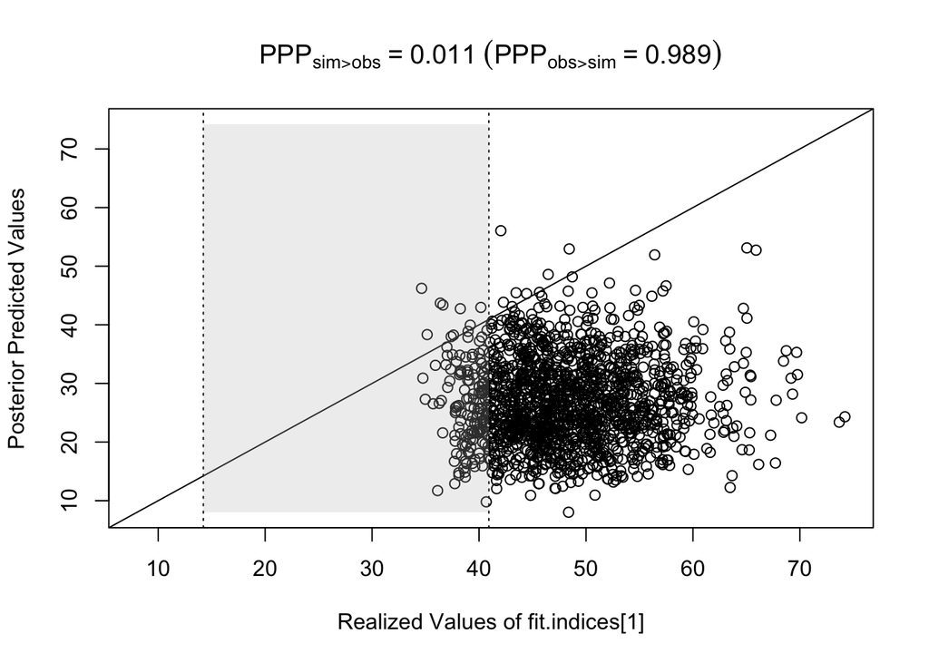

```r
FIs1chisq <- ppmc(CFAfitNonINf, thin=10, fit.measures="chisq")
plot(FIs1chisq)
```

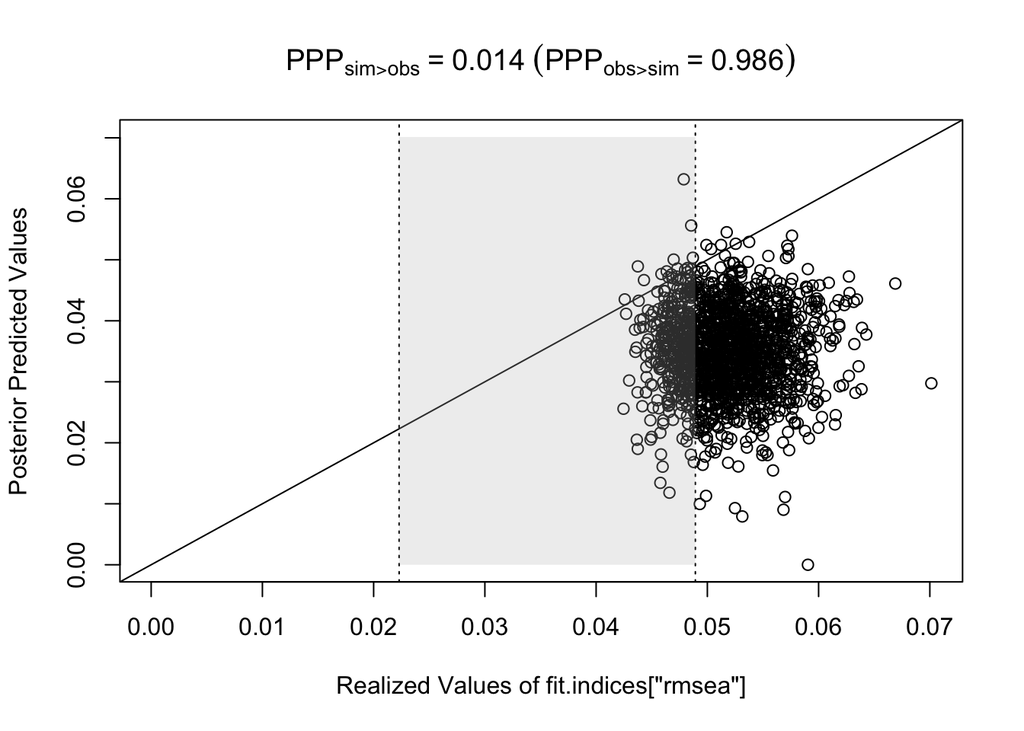

```r
FIs1rmsea <- ppmc(CFAfitNonINf, thin=10, fit.measures="rmsea")
plot(FIs1rmsea)
```

We find on the basis of the PPCs that the model does not fit the data. Note that both the chi-square and RMSEA will be sensitive to the sample size.

# Informative model and model comparison

```r
CanadaCFAmodel2<- ' PosRead =~ dowell+easy+interesting
                    NegRead =~ harder+difficultwords+otherthings'
```

Here we run the analysis and obtain the summary. The number of chains is 3 by default. We control the number of burnin and post-burnin samples. Here, for simplicity we put an informative prior on the loadings and leave the other parameters at their default priors.

```r
CFAfitINf <- bcfa(CanadaCFAmodel2, data=CanadaCFA, burnin = 5000, sample=5000,bcontrol=list(cores=4),dp=dpriors(lambda="normal(.7,1)"))
```

```
## Computing posterior predictives...
```

We can look at the default priors used by blavaan

```r
blavInspect(CFAfitINf, "dp")
```

```
##                nu             alpha            lambda              beta
##    "normal(0,32)"    "normal(0,10)"    "normal(.7,1)"    "normal(0,10)"
##             theta               psi               rho             ibpsi
## "gamma(1,.5)[sd]" "gamma(1,.5)[sd]"       "beta(1,1)" "wishart(3,iden)"
##               tau             delta
## "normal(0,10^.5)" "gamma(1,.5)[sd]"
```

# Trace and density plots

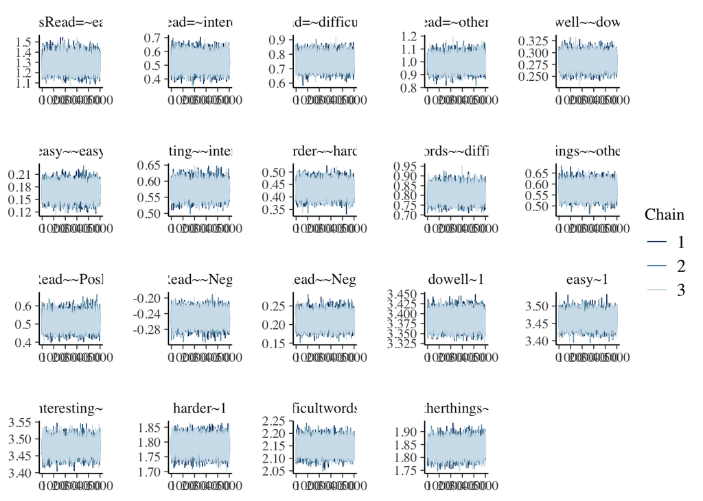

```r
plot(CFAfitINf,plot.type=c("trace"))
```

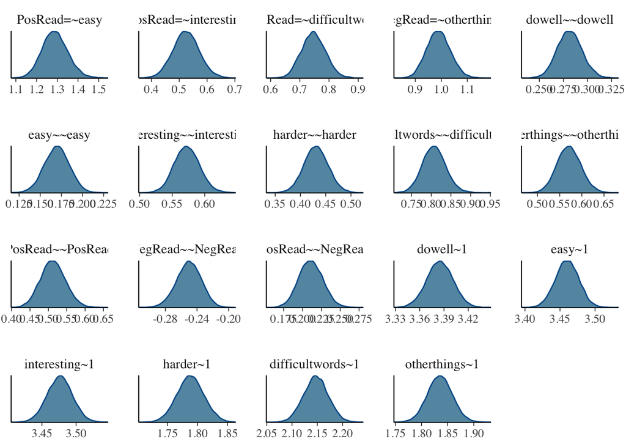

```r
plot(CFAfitINf,plot.type=c("dens"))
```

```r
blavInspect(CFAfitINf, "psrf")
```

```
##                  PosRead=~easy           PosRead=~interesting
##                      1.0002190                      0.9998697
##        NegRead=~difficultwords           NegRead=~otherthings
##                      0.9999360                      1.0001499
##                 dowell~~dowell                     easy~~easy
##                      1.0000327                      1.0000455
##       interesting~~interesting                 harder~~harder
##                      1.0000995                      0.9999484
## difficultwords~~difficultwords       otherthings~~otherthings
##                      0.9999017                      0.9999657
##               PosRead~~PosRead               NegRead~~NegRead
##                      1.0001613                      1.0002130
##               PosRead~~NegRead                       dowell~1
##                      1.0001728                      1.0000542
##                         easy~1                  interesting~1
##                      1.0003533                      0.9999064
##                       harder~1               difficultwords~1
##                      1.0003805                      0.9999715
##                  otherthings~1
##                      1.0000120
```

The convergence diagnostics look good.

# Results

```r
blavInspect(CFAfitINf, "postmean")
```

```
##                  PosRead=~easy           PosRead=~interesting
##                      1.2891990                      0.5247309
##        NegRead=~difficultwords           NegRead=~otherthings
##                      0.7470006                      0.9896577
##                 dowell~~dowell                     easy~~easy
##                      0.2814817                      0.1696614
##       interesting~~interesting                 harder~~harder
##                      0.5728230                      0.4309545
## difficultwords~~difficultwords       otherthings~~otherthings
##                      0.8073799                      0.5710236
##               PosRead~~PosRead               NegRead~~NegRead
##                      0.2111180                      0.5128173
##               PosRead~~NegRead                       dowell~1
##                     -0.2503209                      3.3849387
##                         easy~1                  interesting~1
##                      3.4601338                      3.4761662
##                       harder~1               difficultwords~1
##                      1.7883099                      2.1474025
##                  otherthings~1
##                      1.8352547
```

```r
blavInspect(CFAfitINf, "hpd")
```

```
##                                     lower      upper
## PosRead=~easy                   1.1749985  1.4144885
## PosRead=~interesting            0.4329272  0.6170025
## NegRead=~difficultwords         0.6683339  0.8247970
## NegRead=~otherthings            0.9016979  1.0756277
## dowell~~dowell                  0.2574973  0.3071494
## easy~~easy                      0.1401752  0.1974917
## interesting~~interesting        0.5351100  0.6103371
## harder~~harder                  0.3832482  0.4772944
## difficultwords~~difficultwords  0.7493695  0.8654139
## otherthings~~otherthings        0.5157816  0.6210787
## PosRead~~PosRead                0.1803824  0.2418560
## NegRead~~NegRead                0.4500493  0.5815188
## PosRead~~NegRead               -0.2810357 -0.2205293
## dowell~1                        3.3530134  3.4162978
## easy~1                          3.4269400  3.4917998
## interesting~1                   3.4398252  3.5114593
## harder~1                        1.7465170  1.8341047
## difficultwords~1                2.1006613  2.1947720
## otherthings~1                   1.7908175  1.8839060
## attr(,"Probability")
## [1] 0.95
```

Posterior predictive checks using two common methods for assessing the quality of the fit in CFA

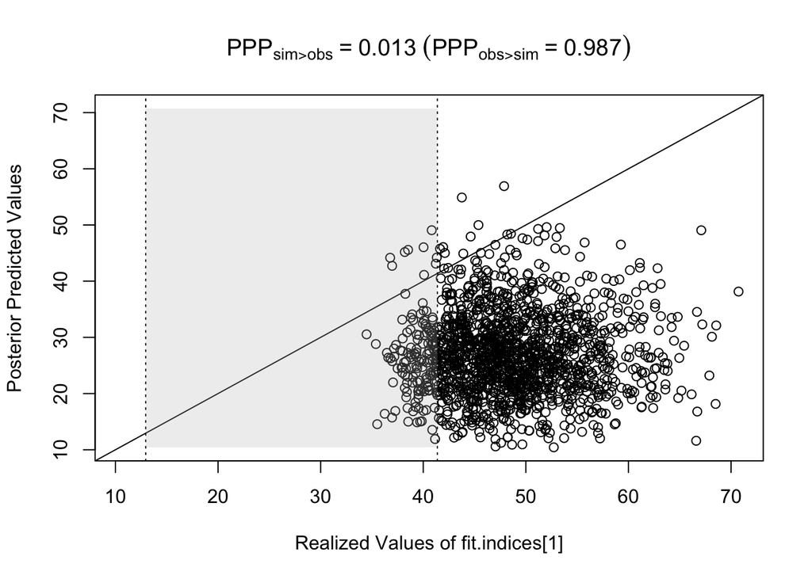

```r
FIs2chisq <- ppmc(CFAfitINf, thin=10, fit.measures="chisq")
plot(FIs2chisq)
```

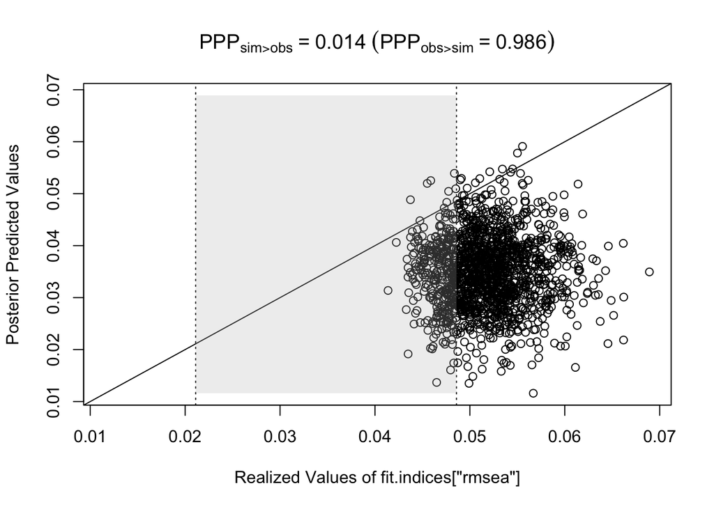

```r
FIs2rmsea <- ppmc(CFAfitINf, thin=10, fit.measures="rmsea")
plot(FIs2rmsea)
```

For both models, the posterior predictive p-value shows considerable lack of fit. Note that both the chi-square and RMSEA will be sensitive to the sample size.

Compare non-informative and informative models using LOO, WAIC, and the log-Bayes factor

```r
blavCompare(CFAfitNonINf,CFAfitINf)
```

```
##
## WAIC estimates:
##  object1:  26340.684
##  object2:  26340.856
##
## WAIC difference & SE:
##    -0.086    0.077
##
## LOO estimates:
##  object1:  26340.703
##  object2:  26340.87
##
## LOO difference & SE:
##    -0.084    0.077
##
## Laplace approximation to the log-Bayes factor
## (experimental; positive values favor object1):   -9.055
```